# Midterm

## Questions 10 and 11

This code identifies the genes that are common to samples 143 and 159. It then calculates the mean expression of human mRNA and protein for all those genes in both data sets and for does the same for chimp. Scatter plots are drawn to compare mean human mRNA across 143 and 159, mean human protein across 143 and 159, mean chimp mRNA across 143 and 159, and mean chimp protein across 143 and 159.

This data illustrates a near perfect, if not perfect, linear relationship between sample 143 human mRNA expression levels and sample 159 human mRNA expression levels for the 96 identified shared genes. The same pattern applies to chimpanzee as well. For each of the 96 genes, the scatter plots imply that if gene x is expressed highly in sample 159, it is also expressed as highly in sample 143.

For protein expression, the relationship is less clear. There appears to be a potential negative linear relationship between sample 143 human protein expression levels and sample 159 human protein expression levels for the 96 identified shared genes. Again,the same pattern applies to chimpanzee protein expression between samples.This indicates that if gene x is expressed highly in sample 159, that gene is actually expressed at a lower level in sample 143.

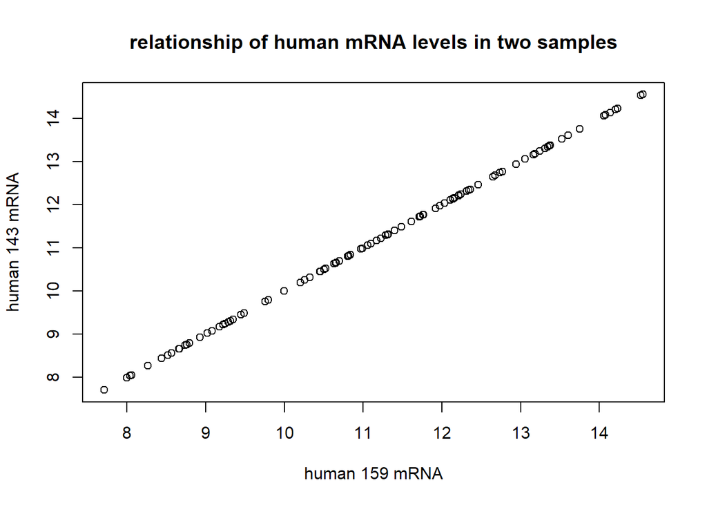

```r
seq_id<-c(rownames(r.143)[c(rownames(r.143)) %in% c(rownames(r.159))])
m.mu<-matrix(0,nrow=length(seq_id),ncol=12)
rownames(m.mu)<-seq_id
colnames(m.mu)<-c("h.r.143","h.r.159","h.r.pval","h.p.143","h.p.159","h.p.pval","c.r.143","c.r.159","c.r.pval","c.p.143","c.p.159","c.p.pval")

for (id in 1:length(seq_id)){
  h.mu.143<-apply(r.143[seq_id[id],9:14],1,mean)
  m.mu[id,1]<-h.mu.143
  h.mu.159<-apply(r.159[seq_id[id],9:14],1,mean)
  m.mu[id,2]<-h.mu.159
  m.mu[id,3]<-t.test(r.143[seq_id[id],9:14],r.159[seq_id[id],9:14])$p.value
  h.mu.143<-apply(r.143[seq_id[id],18:20],1,mean)
  m.mu[id,4]<-h.mu.143
  h.mu.159<-apply(r.159[seq_id[id],18:20],1,mean)
  m.mu[id,5]<-h.mu.159
  m.mu[id,6]<-t.test(r.143[seq_id[id],18:20],r.159[seq_id[id],18:20])$p.value
  c.mu.143<-apply(r.143[seq_id[id],3:8],1,mean)
  m.mu[id,7]<-c.mu.143
  c.mu.159<-apply(r.159[seq_id[id],3:8],1,mean)
  m.mu[id,8]<-c.mu.159
  m.mu[id,9]<-t.test(r.143[seq_id[id],3:8],r.159[seq_id[id],3:8])$p.value
  c.mu.143<-apply(r.143[seq_id[id],15:17],1,mean)
  m.mu[id,10]<-c.mu.143
  c.mu.159<-apply(r.159[seq_id[id],15:17],1,mean)
  m.mu[id,11]<-c.mu.159
  m.mu[id,12]<-t.test(r.143[seq_id[id],15:14],r.159[seq_id[id],15:17])$p.value
}
plot(m.mu[,1],m.mu[,2],xlab="human 159 mRNA",ylab="human 143 mRNA",main="relationship of human mRNA levels in two samples")
```

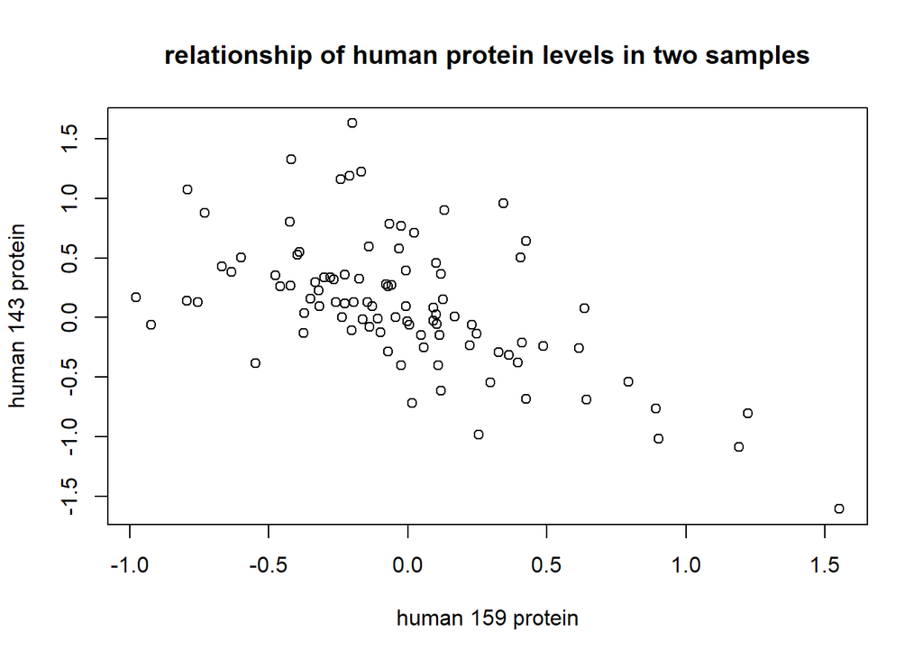

```r
plot(m.mu[,4],m.mu[,5],xlab="human 159 protein",ylab="human 143 protein",main="relationship of human protein levels in two samples")
```

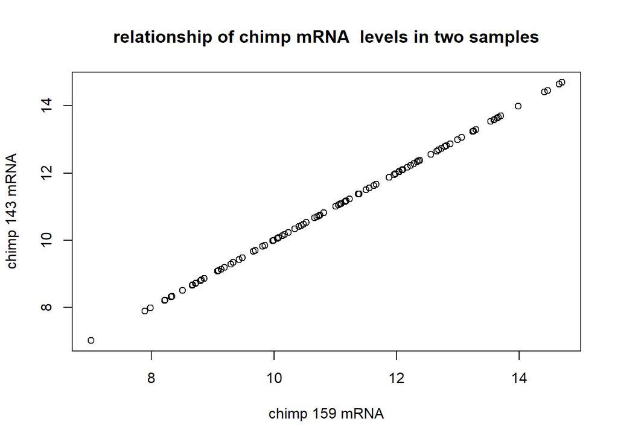

```r
plot(m.mu[,7],m.mu[,8],xlab="chimp 159 mRNA",ylab="chimp 143 mRNA",main="relationship of chimp mRNA  levels in two samples")
```

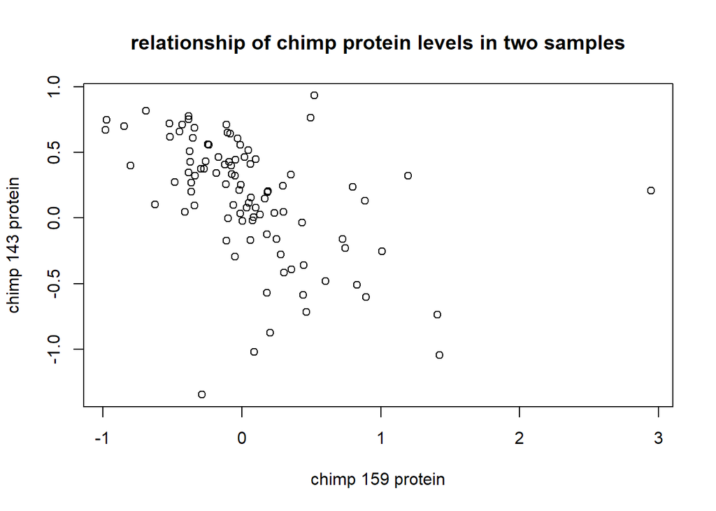

```r
plot(m.mu[,10],m.mu[,11],xlab="chimp 159 protein",ylab="chimp 143 protein",main="relationship of chimp protein levels in two samples")
```

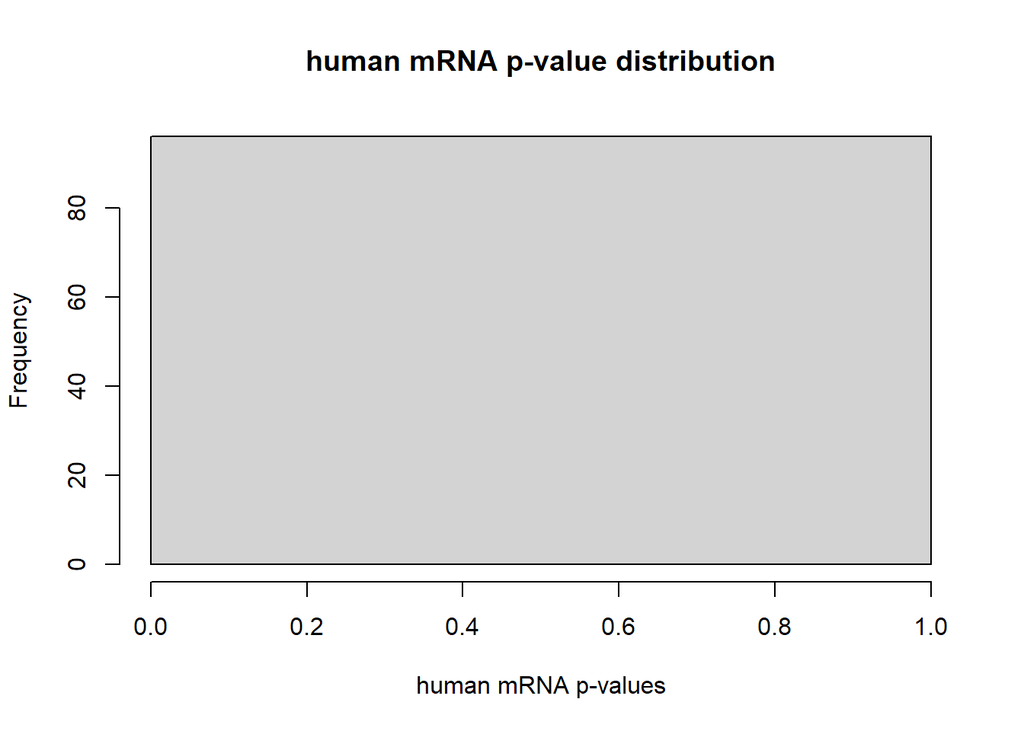

```r
hist(m.mu[,3],xlab="human mRNA p-values",main="human mRNA p-value distribution")
```